# Análisis de tablas de contingencia

Por Cindy Camacho y Santiago Cárdenas

Especialización en Análisis de Datos en Ciencias Sociales

# Introducción

La investigación utiliza datos de la Encuesta de Delito Organizado 2015 realizada por el Laboratorio de Ciencias Sociales (LACSO) y el Observatorio Venezolano de Violencia (OVV), aplicada a 3500 hogares mediante un muestreo semiprobabilístico . El estudio se fundamenta en la propuesta de Von Lampe (2011), poniendo énfasis en la paradoja del Estado como ente regulador que, por ineficiencia o exceso, puede generar oportunidades para el delito.

Las variables seleccionadas para este análisis de modelos log-lineales son:

- Variable independiente: que mide la creencia en el involucramiento de los militares con el Delito Organizado.
- Variable dependiente: que mide el grado de acuerdo con que los tribunales condenan a los culpables.
- Variable de estratificación: correspondiente a la autodefinición política del encuestado .

Se emplearon las librerías tidyverse y haven para la importación, selección y depuración de la base de datos. El objetivo principal fue transformar las variables originales (con etiquetas de SPSS) en factores ordenados adecuados para el análisis de asociación ordinal. Se aplicó un filtro estricto para eliminar la categoría “No sabe” y los valores perdidos (NA).

Se seleccionaron las variables originales y se realizó una recodificación explícita donde la opción “No sabe” fue convertida a NA (valor perdido). Se eliminaron los niveles vacíos con droplevels, reduciendo las dimensiones de las variables a 3 niveles con la variable independiente (Nada, Más o menos, Muy involucrados) y a 5 niveles con la variable dependiente (Muy desacuerdo a Muy de acuerdo). Adicionalmente, se forzó el orden de los factores para garantizar una escala monótona creciente (1 < 2 < 3…).

La eliminación de la categoría “No sabe” es una decisión metodológica crucial basada en la naturaleza de las pruebas a realizar. Según Aguilera del Pino (2006) para aplicar pruebas de tendencia (como Cochran-Mantel-Haenszel) o calcular Razones de Ventajas Locales, es requisito indispensable que las variables sean ordinales. Incluir la opción “No sabe” convertiría a las variables en nominales (sin orden lógico), impidiendo detectar si “a mayor percepción de corrupción militar, menor confianza en tribunales”. Al limpiar y ordenar los factores, aseguramos que los scores asignados en el análisis posterior reflejen correctamente la intensidad de la opinión.

# Análisis

## Preparación de los datos

En primer lugar, se cargaron los paquetes y librerías necesarias.

```r
#install.packages("haven")
#install.packages("tidyverse")
#install.packages("janitor")
#install.packages("vcd")
#install.packages("vcdExtra")
#install.packages("quarto")
library(haven)
library(tidyverse)
library(labelled)
library(dplyr)
library(grid)
library(broom)
library(knitr)
```

Luego, se cargaron los datos y se inspeccionó la clase

```r
DO_2015_APGEA_mll25 <- read_sav("Primera tarea/DO_2015_APGEA_mll25.sav")
dobase <- DO_2015_APGEA_mll25
base::class(dobase)
```

```
[1] "tbl_df"     "tbl"        "data.frame"
```

Se creó un nuevo data frame incorporando las variables necesarias para el análisis, en este caso p3a, la cual indaga sobre la creencia del involucramiento de los militares con el DO en la región donde habitaba el entrevistado, con cuatro opciones de respuesta (desde “Nada involucrados” hasta “Muy involucrados”) y la p6b, la cual interroga sobre el grado de acuerdo con que los tribunales condenaban a los culpables del DO con seis opciones de respuesta (desde “Muy en desacuerdo” hasta “Muy de acuerdo”). Adicionalmente se debe incorporó variable DEFPOL_3c que recoge la auto definición política con tres opciones de respuesta (“Chavista”, “Opositor”, “Ninguno”)

```r
do <- dobase |>
  dplyr::select(p3.pdo = p3a,
                p6.gcn = p6b,
                dpol =DEFPOL_3c
  )
base::class(do)
```

```
[1] "tbl_df"     "tbl"        "data.frame"
```

```r
dplyr::glimpse(do)
```

```
Rows: 3,500
Columns: 3
$ p3.pdo <dbl+lbl>  2,  1,  2, NA,  1,  1,  2,  3,  2,  1,  3, NA,  3,  1,  1,…
$ p6.gcn <dbl+lbl>  2,  1,  4,  4,  3,  5,  2,  2,  1, NA,  2,  4,  2,  3,  4,…
$ dpol   <dbl+lbl> 3, 1, 1, 3, 1, 3, 1, 2, 2, 2, 1, 1, 1, 1, 1, 3, 3, 3, 1, 3,…
```

Se transformaron las variables a factores

```r
dofact <- do |>
  dplyr::mutate(
    across(where(is.labelled),
           haven::as_factor))
kable(levels(dofact$p3.pdo), col.names = c("Involucramiento"))
```

| Involucramiento |
| --- |
| Nada involucrados |
| Más o menos |
| Muy involucrados |
| No sabe |

```r
kable(levels(dofact$p6.gcn), col.names = c("Tribunales"))
```

| Tribunales |
| --- |
| Muy en desacuerdo |
| En desacuerdo |
| Ni de acuerdo ni en desacuerdo |
| De acuerdo |
| Muy de acuerdo |
| No sabe |

```r
kable(levels(dofact$dpol), col.names = c("Definición política"))
```

| Definición política |
| --- |
| Chavista |
| Opositor |
| Ninguno |
| No responde |

Se recodificaron los niveles de las variables, se filtraron los valores perdidos y se eliminaron los niveles sin datos

```r
dof <- dofact |>
  dplyr::mutate(
    # Recodificación de P3 (Involucramiento)
    p3f.pdo = dplyr::recode(p3.pdo,
                            "Nada involucrados" = "NadaInvolucrados",
                            "Más o menos" = "Mas/Menos",
                            "Muy involucrados" = "MuyInvolucrados",
                            "No sabe" = NA_character_), # Asignamos NA explícitamente
    # Recodificación de P6 (Tribunales)
    p6f.gcn = dplyr::recode(p6.gcn,
                            "Muy en desacuerdo" = "MuyDesacuerdo",
                            "En desacuerdo" = "EnDesacuerdo",
                            "Ni de acuerdo ni en desacuerdo" = "NiNi",
                            "De acuerdo" = "DeAcuerdo",
                            "Muy de acuerdo" = "MuyAcuerdo",
                            "No sabe" = NA_character_)  # Asignamos NA explícitamente
  ) |>
  # Filtramos los NA para quedarnos solo con respuestas válidas
  dplyr::filter(!is.na(p3f.pdo), !is.na(p6f.gcn), !is.na(dpol)) |>
  droplevels() # Eliminamos los niveles vacíos

kable(levels(dof$p3f.pdo), col.names = c("Involucramiento"))
```

| Involucramiento |
| --- |
| NadaInvolucrados |
| Mas/Menos |
| MuyInvolucrados |

```r
kable(levels(dof$p6f.gcn), col.names = c("Tribunales"))
```

| Tribunales |
| --- |
| MuyDesacuerdo |
| EnDesacuerdo |
| NiNi |
| DeAcuerdo |
| MuyAcuerdo |

Se establecieron los niveles adecuados de las variables y se verificó la estructura final

```r
dof$p3f.pdo <- factor(dof$p3f.pdo, levels = c("NadaInvolucrados", "Mas/Menos", "MuyInvolucrados"))
dof$p6f.gcn <- factor(dof$p6f.gcn, levels = c("MuyDesacuerdo", "EnDesacuerdo", "NiNi", "DeAcuerdo", "MuyAcuerdo"))
kable(summary(dof$p3f.pdo), col.names = c("Involucramiento"))
```

|  | Involucramiento |
| --- | --- |
| NadaInvolucrados | 714 |
| Mas/Menos | 1028 |
| MuyInvolucrados | 1025 |

```r
kable(summary(dof$p6f.gcn), col.names=c("Tribunales"))
```

|  | Tribunales |
| --- | --- |
| MuyDesacuerdo | 256 |
| EnDesacuerdo | 1088 |
| NiNi | 349 |
| DeAcuerdo | 886 |
| MuyAcuerdo | 188 |

```r
kable(summary(dof$dpol), col.names=c("Definicion política"))
```

|  | Definicion política |
| --- | --- |
| Chavista | 784 |
| Opositor | 1002 |
| Ninguno | 981 |

## Análisis descriptivo

En primer lugar, se generó la tabla de contingencia completa utilizando la función stats::xtabs. Esta función crea un arreglo multidimensional que cruza todas las variables activas con la variable de estratificación. Se obtuvo un objeto de clase xtabs y table que representa la distribución conjunta de las frecuencias observadas. La estructura resultante es una tabla de 3 x 3 x 5, donde:

- Dimensión 1 (de estratificación): definición política con tres niveles (Chavista, Opositor, Ninguno).
- Dimensión 2 (Filas/Causa): creencia en el involucramiento con el Delito Organizado de los militares con tres niveles (Nada involucrados, Más o menos y Muy involucrados).
- Dimensión 3 (Columnas/Efecto): acuerdo con que los tribunales condenan a los culpables de Delito Organizado con cinco niveles (Muy en desacuerdo, En desacuerdo, Ni de acuerdo ni en desacuerdo, De acuerdo y Muy de acuerdo).

La visualización plana (ftable) muestra cómo se distribuyen los 3500 casos originales (menos los perdidos) a través de estas intersecciones. La construcción de esta tabla es el paso preliminar para el análisis de asociación. Siguiendo a Aguilera del Pino, esta tabla multidimensional *I x J x K* contiene la información necesaria para estudiar tanto la independencia marginal (colapsando variables) como la independencia condicional (controlando por el estrato político). Al incluir dpol en la creación de la tabla madre, reconocemos teóricamente que la relación entre la percepción de los militares y los tribunales podría no ser homogénea en toda la población, sino que podría estar confundida o modificada por la postura política del encuestado (fenómeno de interacción o modificación de efecto).

```r
dof_tab<-stats::xtabs(~dpol + p3f.pdo+p6f.gcn,data=dof)
base::class(dof_tab)
```

```
[1] "xtabs" "table"
```

```r
stats::ftable(dof_tab)
```

```
                          p6f.gcn MuyDesacuerdo EnDesacuerdo NiNi DeAcuerdo MuyAcuerdo
dpol     p3f.pdo
Chavista NadaInvolucrados                    17           47   25       157         19
         Mas/Menos                            6           81   37       135         32
         MuyInvolucrados                     12           68   21       103         24
Opositor NadaInvolucrados                    12           63   23        54          6
         Mas/Menos                           44          177   52        68         13
         MuyInvolucrados                    104          261   38        60         27
Ninguno  NadaInvolucrados                    13           84   42       143          9
         Mas/Menos                           19          166   69       104         25
         MuyInvolucrados                     29          141   42        62         33
```

Luego, se generó una tabla de contingencia que cruza las variables activas, la cual muestra que el grupo más numeroso de la muestra, con 1088 casos, se ubica en la categoría de “En Desacuerdo” respecto a la condena de culpables por parte de los tribunales. Dentro de este grupo, la mayor acumulación de respuestas (470 personas) percibe que los militares están “Muy Involucrados” con el delito organizado, lo que refleja una coincidencia masiva entre la desconfianza en el sistema de justicia penal y la percepción de corrupción en el estamento militar en la región del encuestado. Por otro lado, la categoría de confianza institucional “De Acuerdo”, aunque cuenta con 886 casos, tiene su mayor frecuencia (354 personas) en la opción de militares “Nada Involucrados”, sugiriendo un bloque de opinión que percibe coherencia en la integridad de las instituciones del Estado.

Este patrón de frecuencias confirma que los datos no se distribuyen al azar, sino que tienden a agruparse en los extremos de baja confianza/alta corrupción y alta confianza/baja corrupción, dando indicios de asociación estadística. Es particularmente revelador que, de los 256 casos que están en “Muy en Desacuerdo” con los tribunales, la mayoría (145) opina que los militares están “Muy Involucrados”, mientras que en el extremo de “Muy de Acuerdo” (188 casos), la percepción de militares “Muy Involucrados” cae a 84 casos. Esta distribución apoya la tesis de Von Lampe (2011) sobre cómo la ineficiencia percibida en la regulación y sanción estatal (los tribunales) se vincula directamente con la creencia de que existen estructuras que facilitan el delito organizado (los militares).

```r
#MARGEN PARA LAS VARIABLES ACTIVAS
do_23 <- base::margin.table(dof_tab,
                            margin=c(2,3))
kable(do_23)
```

|  | MuyDesacuerdo | EnDesacuerdo | NiNi | DeAcuerdo | MuyAcuerdo |
| --- | --- | --- | --- | --- | --- |
| NadaInvolucrados | 42 | 194 | 90 | 354 | 34 |
| Mas/Menos | 69 | 424 | 158 | 307 | 70 |
| MuyInvolucrados | 145 | 470 | 101 | 225 | 84 |

Luego, se computaron los margenes totales y se hicieron agregaciones para calcular porcentajes por filas, por columnas y sobre el total

```r
#MARGENES TOTALES Y CALCULOS DE PORCENTAJES
do_23tib <- do_23 |>
  as_tibble() |>
  pivot_wider(names_from = p6f.gcn, values_from = n) |>
  janitor::clean_names() # Opcional: limpiar nombres de columnas
kable(do_23tib, digits=4)
```

| p3f_pdo | muy_desacuerdo | en_desacuerdo | ni_ni | de_acuerdo | muy_acuerdo |
| --- | --- | --- | --- | --- | --- |
| NadaInvolucrados | 42 | 194 | 90 | 354 | 34 |
| Mas/Menos | 69 | 424 | 158 | 307 | 70 |
| MuyInvolucrados | 145 | 470 | 101 | 225 | 84 |

```r
#AGREGACION TOTALES POR FILAS Y COLUMNAS
do_23mtot <- do_23tib |>
  janitor::adorn_totals(where = c("row", "col"))
kable(do_23mtot)
```

| p3f_pdo | muy_desacuerdo | en_desacuerdo | ni_ni | de_acuerdo | muy_acuerdo | Total |
| --- | --- | --- | --- | --- | --- | --- |
| NadaInvolucrados | 42 | 194 | 90 | 354 | 34 | 714 |
| Mas/Menos | 69 | 424 | 158 | 307 | 70 | 1028 |
| MuyInvolucrados | 145 | 470 | 101 | 225 | 84 | 1025 |
| Total | 256 | 1088 | 349 | 886 | 188 | 2767 |

Se calcularon los Perfiles columna de la tabla de contingencia. Este procedimiento consiste en calcular la distribución porcentual verticalmente, tomando como base (100%) el total de cada categoría de la variable respuesta (Tribunales). Siguiendo a Aguilera del Pino (2006), los perfiles columna nos permiten realizar un análisis “retrospectivo” o de composición. Mientras que los perfiles fila nos hablan de causalidad (efecto de X sobre Y), los perfiles columna nos permiten caracterizar a los grupos de opinión. Nos ayuda a responder: “¿Quiénes son los ciudadanos que desconfían radicalmente de los tribunales? ¿Qué creencia sobre los militares predomina en este grupo?”.

Los resultados muestran que el 56,6% de quienes están “Muy en Desacuerdo” con los tribunales provienen del grupo que cree que los militares están “Muy Involucrados” en delitos. Solo un pequeño 16,4% de este grupo cree que los militares no están involucrados.

La composición cambia en el grupo que valida a los tribunales. Aquí, la categoría predominante es la de quienes creen que los militares están “Nada Involucrados” (40.0%), mientras que los que creen que están “Muy Involucrados” se reducen al 25.4%.

```r
#CALCULO DE PORCENTAJES POR COLUMNAS
do_23pcol <- do_23mtot |>
  janitor::adorn_percentages(denominator = "col") |>
  janitor::adorn_pct_formatting(digits = 1)
kable(do_23pcol)
```

| p3f_pdo | muy_desacuerdo | en_desacuerdo | ni_ni | de_acuerdo | muy_acuerdo | Total |
| --- | --- | --- | --- | --- | --- | --- |
| NadaInvolucrados | 16.4% | 17.8% | 25.8% | 40.0% | 18.1% | 25.8% |
| Mas/Menos | 27.0% | 39.0% | 45.3% | 34.7% | 37.2% | 37.2% |
| MuyInvolucrados | 56.6% | 43.2% | 28.9% | 25.4% | 44.7% | 37.0% |
| Total | 100.0% | 100.0% | 100.0% | 100.0% | 100.0% | 100.0% |

Al mismo tiempo, se calcularon los Perfiles fila para estudiar dependencia condicional desde una perspectiva causal. Al haber colocado la variable “causa” (Involucramiento Militar) en las filas, los porcentajes nos permiten responder a la pregunta: “Dado un nivel específico de percepción de corrupción militar, ¿cuál es la probabilidad condicionada de confiar o desconfiar de los tribunales?”.

Al comparar las distribuciones porcentuales en el Grupo “Nada involucrados”, predomina la confianza institucional. El 49.6% de este grupo manifiesta estar “De acuerdo” con que los tribunales condenan a los culpables, siendo la categoría modal (la más frecuente). El rechazo radical (“Muy en desacuerdo”) es marginal, debido a que representa solo el 5,9% entre los grupos extremos.

En el grupo “Muy involucrados” la tendencia se invierte drásticamente hacia la desconfianza. El porcentaje de personas que están “De Acuerdo” con los tribunales cae abruptamente al 22.0% (menos de la mitad que en el primer grupo). Por el contrario, la categoría “En Desacuerdo” se convierte en la mayoritaria con un 45,9%, y el rechazo radical (“Muy en Desacuerdo”) sube al 14,1%.

La variabilidad de los perfiles fila demuestra ya de antemano que es muy probable que la opinión sobre los tribunales no sea independiente de la opinión sobre los militares. Por lo tanto, hay información inicial sobre una posible asociación negativa monótona: a mayor percepción de corrupción en el aparato de seguridad (militares), menor legitimidad se le otorga al aparato de justicia (tribunales).

```r
#CALCULO DE PORCENTAJES POR FILAS
do_23prow <- do_23mtot |>
  janitor::adorn_percentages(denominator = "row") |>
  janitor::adorn_pct_formatting(digits = 1)
kable(do_23prow)
```

| p3f_pdo | muy_desacuerdo | en_desacuerdo | ni_ni | de_acuerdo | muy_acuerdo | Total |
| --- | --- | --- | --- | --- | --- | --- |
| NadaInvolucrados | 5.9% | 27.2% | 12.6% | 49.6% | 4.8% | 100.0% |
| Mas/Menos | 6.7% | 41.2% | 15.4% | 29.9% | 6.8% | 100.0% |
| MuyInvolucrados | 14.1% | 45.9% | 9.9% | 22.0% | 8.2% | 100.0% |
| Total | 9.3% | 39.3% | 12.6% | 32.0% | 6.8% | 100.0% |

Por último, se calcularon los Porcentajes Totales (o frecuencias relativas conjuntas) de la tabla I x J. Los porcentajes totales representan la distribución conjunta de las variables. A diferencia de los perfiles (que miran hacia adentro de una fila o columna), los porcentajes totales nos permiten identificar el peso relativo de cada perfil de ciudadano en el conjunto global de la población. Su función es localizar dónde se encuentra la “masa” de los datos y detectar qué combinaciones de creencias son las más frecuentes en la sociedad venezolana.

La combinación más común en la muestra es la de ciudadanos que creen que los militares están “Muy involucrados” y que, simultáneamente, están “En desacuerdo” con que los tribunales condenen a los culpables. Este grupo representa el 17% de toda la población encuestada. El perfil de quienes perciben un involucramiento militar “Más o Menos” y están “En desacuerdo” con los tribunales, que constituye el 15,3% del total.

En el extremo opuesto, el ciudadano que cree que los militares no están “Nada involucrados” y está “Muy de Acuerdo” con los tribunales representa apenas el 1,2% de la muestra. De forma global, el 48,6% de la muestra total (casi la mitad de los venezolanos en 2015) se ubica en alguna de las dos categorías de descontento con los tribunales (“En desacuerdo” o “Muy en desacuerdo”).

```r
#CALCULO DE PORCENTAJES SOBRE EL TOTAL DE LA TABLA
do_23ptot <- do_23mtot |>
  janitor::adorn_percentages(denominator = "all") |>
  janitor::adorn_pct_formatting(digits = 1)
kable(do_23ptot)
```

| p3f_pdo | muy_desacuerdo | en_desacuerdo | ni_ni | de_acuerdo | muy_acuerdo | Total |
| --- | --- | --- | --- | --- | --- | --- |
| NadaInvolucrados | 1.5% | 7.0% | 3.3% | 12.8% | 1.2% | 25.8% |
| Mas/Menos | 2.5% | 15.3% | 5.7% | 11.1% | 2.5% | 37.2% |
| MuyInvolucrados | 5.2% | 17.0% | 3.7% | 8.1% | 3.0% | 37.0% |
| Total | 9.3% | 39.3% | 12.6% | 32.0% | 6.8% | 100.0% |

## Análisis inferencial

### Asociación

Teniendo en cuenta la asociación observada a partir de las frecuencias en las tablas de contingencia y haciendo uso de la función assocstats del paquete vcd, se computaron los estadísticos de asociación y la prueba de independencia para evaluar la significancia estadística de esta relación. Los resultados del análisis estadístico confirman de manera contundente la existencia de una relación entre la percepción del involucramiento de los militares con el delito organizado y el grado de acuerdo con la actuación de los tribunales. Tanto la prueba de razón de verosimilitud, *G<sup>2</sup>*<sub>(8,2767)</sub> = 199.37, *p* < .001, como la prueba de chi-cuadrado de Pearson, *X<sup>2</sup>*<sub>(8, 2767)</sub> = 203.75, *p* < .001, proporcionan evidencia suficiente para rechazar la hipótesis de independencia. Esto implica que la opinión que los ciudadanos mantienen sobre la integridad de las fuerzas armadas en su región está vinculada estadísticamente a su juicio sobre la eficacia del sistema judicial para condenar a los culpables.

En cuanto a la magnitud de esta asociación, el coeficiente V de Cramer arroja un valor de *V*=.19, mientras que el coeficiente de contingencia se sitúa en *C*=.26. Según los criterios de interpretación de Aguilera (2006) para el análisis de tablas de contingencia, estos estadísticos indican que la fuerza de la relación es de una intensidad moderada-baja. Esto significa que, si bien existe un patrón sistemático donde la desconfianza en una institución suele acompañar a la percepción de corrupción en la otra, la relación no es absoluta ni determinante, lo que sugiere que las valoraciones de los hogares encuestados están influidas por otros factores adicionales que no se limitan exclusivamente al cruce de estas dos variables estatales.

```r
vcd::assocstats(do_23)
```

```
                    X^2 df P(> X^2)
Likelihood Ratio 199.37  8        0
Pearson          203.75  8        0

Phi-Coefficient   : NA
Contingency Coeff.: 0.262
Cramer's V        : 0.192
```

### Ventajas locales

Se calcularon las Razones de Ventajas Locales para la tabla de contingencia. Según Aguilera del Pino (2006), mientras que la prueba Chi-cuadrado nos dice si hay relación, las razones de ventajas locales nos dicen dónde y cómo ocurre esa relación en variables ordinales. Este estadístico compara celdas adyacentes en la tabla. Específicamente, evalúa si el cambio de una categoría a la siguiente en la variable X (Involucramiento) produce un cambio proporcional en la variable Y (Tribunales). Un valor de 1 indica independencia local (la opinión no cambia en ese tramo) mientras que un valor alejado de 1 indica una asociación fuerte en ese punto específico de la escala.

Al analizar la matriz de odds ratios locales, observamos comportamientos heterogéneos que revelan la complejidad del fenómeno. El valor más revelador se encuentra al comparar el paso de “Nada involucrados” a “Más o menos” con respecto a la opinión “Ni de acuerdo/Ni desacuerdo” vs “De acuerdo”. El valor de 0.49 indica que, al pasar de creer que los militares no están involucrados a tener una leve sospecha (“Más o menos”), la probabilidad (odds) de mantener una postura favorable hacia los tribunales se reduce a la mitad. Es decir, basta una sospecha leve de corrupción militar para que se rompa la confianza en la justicia.

Al movernos a la parte baja de la tabla (comparando “Más o menos” con “Muy involucrados”), encontramos un valor de 0.53 en el extremo de la desconfianza (“Muy en desacuerdo”). Esto indica que el paso hacia la convicción firme de corrupción militar (“Muy involucrados”) acelera drásticamente la caída en la legitimidad de los tribunales.

Los resultados de las ventajas locales refutan la hipótesis de que el deterioro de la imagen institucional es lineal o uniforme. Por el contrario, los datos sugieren un efecto umbral. Los valores consistentemente bajos en el centro de la tabla indican que la “contaminación” de la imagen institucional es sistemática. A la luz de la teoría del OVV, esto implica que para el ciudadano venezolano promedio, la integridad del Estado es indivisible: en cuanto se percibe una mancha en el componente de seguridad (militares), la presunción de justicia (tribunales) se derrumba desproporcionadamente.

```r
#VENTAJAS LOCALES EN ESCALA LOGARITMICA
do23_lrvl<-vcd::loddsratio(do_23)
kable(do23_lrvl)
```

| p3f.pdo | p6f.gcn | LOR | ASE |
| --- | --- | --- | --- |
| NadaInvolucrados:Mas/Menos | MuyDesacuerdo:EnDesacuerdo | 0.2854384 | 0.2140453 |
| Mas/Menos:MuyInvolucrados | MuyDesacuerdo:EnDesacuerdo | -0.6396280 | 0.1608585 |
| NadaInvolucrados:Mas/Menos | EnDesacuerdo:NiNi | -0.2190899 | 0.1579663 |
| Mas/Menos:MuyInvolucrados | EnDesacuerdo:NiNi | -0.5504738 | 0.1439314 |
| NadaInvolucrados:Mas/Menos | NiNi:DeAcuerdo | -0.7052345 | 0.1533702 |
| Mas/Menos:MuyInvolucrados | NiNi:DeAcuerdo | 0.1367272 | 0.1546993 |
| NadaInvolucrados:Mas/Menos | DeAcuerdo:MuyAcuerdo | 0.8645839 | 0.2231136 |
| Mas/Menos:MuyInvolucrados | DeAcuerdo:MuyAcuerdo | 0.4930689 | 0.1840985 |

### Odds ratios

Con la finalidad de cuantificar la fuerza de la asociación entre la percepción del involucramiento militar y la confianza en los tribunales, indicando cuánto aumenta o disminuye la probabilidad de una opinión frente a otra al comparar categorías adyacentes, se calcularon las razones de ventaja (odds ratios). En el primer bloque de análisis, el paso de la desconfianza extrema a la desconfianza moderada en los tribunales (“Muy Desacuerdo” frente a “En Desacuerdo”) muestra que la ventaja de percibir a los militares como “Nada Involucrados” frente a “Más o Menos” es de 1.33. Sin embargo, en ese mismo tramo judicial, la ventaja de percibir a los militares como “Más o Menos” frente a “Muy Involucrados” es de 0.52. Esto significa que, entre quienes desconfían de los tribunales, la probabilidad de ver un involucramiento militar moderado es un 48% menor que la de percibirlos como “Muy Involucrados”, confirmando una fuerte asociación entre la crítica judicial y la percepción de alta criminalidad militar.

Al evaluar el tránsito hacia niveles de mayor confianza en la justicia, se observan efectos más pronunciados. En la comparación entre “En Desacuerdo” y la postura neutral (“NiNi”), la ventaja de percibir a los militares como “Más o Menos” frente a “Muy Involucrados” es de 0.57, lo que refuerza que la percepción de máxima corrupción militar se concentra en quienes descalifican al sistema judicial. Por otro lado, al pasar de la neutralidad a estar “De Acuerdo” con los tribunales, la ventaja de percibir a los militares como “Nada Involucrados” frente a “Más o Menos” es de apenas 0.49, indicando que la probabilidad de una imagen militar limpia es un 51% menor en el grupo neutral comparado con el grupo que confía en la justicia.

Finalmente, en el extremo de máxima aprobación institucional (“De Acuerdo” frente a “Muy de Acuerdo”), se encuentran las ventajas más altas del modelo. La probabilidad de percibir a los militares como “Nada Involucrados” frente a “Más o Menos” es 2.37 veces mayor entre quienes están “Muy de Acuerdo” con los tribunales. De igual forma, la ventaja de percibir un involucramiento “Más o Menos” frente a “Muy Involucrados” es de 1.63 en este mismo grupo. Estos valores superiores a 1 confirman que la confianza plena en el sistema judicial actúa como un fuerte predictor de una imagen militar más íntegra, validando la tesis de que los ciudadanos tienden a evaluar la transparencia del Estado como un todo sistémico.

```r
#EXPONENCIAMOS PARA OBTENER RAZONES DE VENTAJAS(ODDS RATIOS)
kable(exp(coef(do23_lrvl)))
```

|  | x |
| --- | --- |
| NadaInvolucrados:Mas/Menos/MuyDesacuerdo:EnDesacuerdo | 1.3303451 |
| Mas/Menos:MuyInvolucrados/MuyDesacuerdo:EnDesacuerdo | 0.5274886 |
| NadaInvolucrados:Mas/Menos/EnDesacuerdo:NiNi | 0.8032495 |
| Mas/Menos:MuyInvolucrados/EnDesacuerdo:NiNi | 0.5766765 |
| NadaInvolucrados:Mas/Menos/NiNi:DeAcuerdo | 0.4939927 |
| Mas/Menos:MuyInvolucrados/NiNi:DeAcuerdo | 1.1465153 |
| NadaInvolucrados:Mas/Menos/DeAcuerdo:MuyAcuerdo | 2.3740180 |
| Mas/Menos:MuyInvolucrados/DeAcuerdo:MuyAcuerdo | 1.6373333 |

### Intervalos de confianza de las razones de ventajas locales

Seguidamente, se calcularon los Intervalos de Confianza (IC) al 95% para las Razones de Ventajas Locales, utilizando la transformación exponencial de los errores estándar del log-odds ratio. El intervalo de confianza nos indica el rango de valores entre los cuales se encuentra el verdadero parámetro poblacional con un 95% de certeza.

```r
#INTERVALOS DE CONFIANZA
icrvl<-exp(stats::confint(do23_lrvl))
kable(icrvl,digits=4)
```

|  | 2.5 % | 97.5 % |
| --- | --- | --- |
| NadaInvolucrados:Mas/Menos/MuyDesacuerdo:EnDesacuerdo | 0.8745 | 2.0238 |
| Mas/Menos:MuyInvolucrados/MuyDesacuerdo:EnDesacuerdo | 0.3848 | 0.7230 |
| NadaInvolucrados:Mas/Menos/EnDesacuerdo:NiNi | 0.5894 | 1.0947 |
| Mas/Menos:MuyInvolucrados/EnDesacuerdo:NiNi | 0.4349 | 0.7646 |
| NadaInvolucrados:Mas/Menos/NiNi:DeAcuerdo | 0.3657 | 0.6672 |
| Mas/Menos:MuyInvolucrados/NiNi:DeAcuerdo | 0.8466 | 1.5526 |
| NadaInvolucrados:Mas/Menos/DeAcuerdo:MuyAcuerdo | 1.5331 | 3.6762 |
| Mas/Menos:MuyInvolucrados/DeAcuerdo:MuyAcuerdo | 1.1414 | 2.3488 |

### Pruebas de hipótesis

La interpretación de las pruebas de hipótesis para las ventajas locales permite determinar en qué puntos específicos de la relación entre el involucramiento militar y la confianza judicial existe una asociación estadísticamente significativa. Estas pruebas utilizan el estadístico *z* para evaluar si el Log-Odds Ratio (LOR) de cada interacción es significativamente distinto de cero.

Al analizar el primer tramo de la escala judicial (comparación entre “Muy Desacuerdo” y “En Desacuerdo”), se observa que la transición de una percepción militar de “Nada Involucrados” a “Más o Menos” no es significativa, *z* = 1.33, *p* = .182. No obstante, el paso de “Más o Menos” a “Muy Involucrados” en este mismo nivel de opinión judicial sí muestra una relación altamente significativa, *z* = -3.98, *p* < .001. El valor negativo del estadístico indica que la probabilidad de percibir un involucramiento militar moderado disminuye significativamente en comparación con la percepción de involucramiento alto cuando existe desacuerdo con los tribunales.

Finalmente, en el polo de mayor confianza institucional, las comparaciones entre estar “De Acuerdo” y “Muy de Acuerdo” presentan los estadísticos z positivos más altos de todo el análisis. Tanto la transición de “Nada” a “Más o Menos” involucramiento (*z* = 3.88, *p* < .001) como la de “Más o Menos” a “Muy Involucrados” (*z* = 2.68, *p* = .007) resultan significativas. Estos resultados confirman que en los niveles de máxima aprobación judicial existe una estructura de opinión consistente que favorece la percepción de baja criminalidad militar, validando estadísticamente la asociación bivariada propuesta en el estudio.

```r
#PRUEBA DE HIPOTESIS
thrvl<-base::summary(do23_lrvl)
kable(tidy(thrvl), col.names = c("Interacción", "Estimación", "Error Est.", "Estadístico z", "p-valor"))
```

| Interacción | Estimación | Error Est. | Estadístico z | p-valor |
| --- | --- | --- | --- | --- |
| NadaInvolucrados:Mas/Menos/MuyDesacuerdo:EnDesacuerdo | 0.2854384 | 0.2140453 | 1.3335418 | 0.1823541 |
| Mas/Menos:MuyInvolucrados/MuyDesacuerdo:EnDesacuerdo | -0.6396280 | 0.1608585 | -3.9763396 | 0.0000700 |
| NadaInvolucrados:Mas/Menos/EnDesacuerdo:NiNi | -0.2190899 | 0.1579663 | -1.3869409 | 0.1654598 |
| Mas/Menos:MuyInvolucrados/EnDesacuerdo:NiNi | -0.5504738 | 0.1439314 | -3.8245558 | 0.0001310 |
| NadaInvolucrados:Mas/Menos/NiNi:DeAcuerdo | -0.7052345 | 0.1533702 | -4.5982506 | 0.0000043 |
| Mas/Menos:MuyInvolucrados/NiNi:DeAcuerdo | 0.1367272 | 0.1546993 | 0.8838253 | 0.3767905 |
| NadaInvolucrados:Mas/Menos/DeAcuerdo:MuyAcuerdo | 0.8645839 | 0.2231136 | 3.8750842 | 0.0001066 |
| Mas/Menos:MuyInvolucrados/DeAcuerdo:MuyAcuerdo | 0.4930689 | 0.1840985 | 2.6782889 | 0.0073999 |

### Prueba de Cochran-Mantel-Haenszel

Para el caso del estudio en cuestión, se obtuvo un valor Chi-cuadrado de 97.924 (con 1 grado de libertad) y un *p*-valor de 4.34x10<sup>-23</sup> (*p* < 0.001). El estadístico de asociación general confirma el hallazgo con un Chi-cuadrado de 203.680 (*p* < 0.001).

```r
#PRUEBA DE COCHRAN-MANTEL HAENSZEL
vcdExtra::CMHtest(do_23)
```

```
Cochran-Mantel-Haenszel Statistics for p3f.pdo by p6f.gcn

                 AltHypothesis   Chisq Df       Prob
cor        Nonzero correlation  97.924  1 4.3476e-23
rmeans  Row mean scores differ  98.464  2 4.1573e-22
cmeans  Col mean scores differ 176.811  4 3.6086e-37
general    General association 203.680  8 1.0715e-39
```

## Análisis estratificado

Hasta ahora se ha presentado un análisis centrado en las variables activas, estas son, la creencia del involucramiento de los militares con el delito organizado y el acuerdo con con los tribunales condenan a los culpables del delito organizado. En este punto resulta valioso agregar al análisis una tercera variable que cumple la función de estratificar a los encuestados en términos de sus definiciones políticas, tomando tres valores: “Chavista”, “Opositor” y “Ninguno”. Inicialmente, se computó una tabla que cruza estas variables y se encontró que en el grupo de los “Chavistas”, se observa una marcada inclinación hacia la confianza institucional. La frecuencia más alta en este segmento se encuentra en la intersección de quienes creen que los militares no están “Nada Involucrados” y están “De Acuerdo” con el desempeño de los tribunales, sumando 157 personas. Es notable que, incluso entre los simpatizantes del gobierno que perciben un involucramiento militar alto o moderado, la mayoría sigue manifestando acuerdo con las condenas de los tribunales (135 y 103 personas respectivamente), lo que sugiere una lealtad institucional que trasciende la percepción del delito regional.

Por el contrario, el grupo de los “Opositores” refleja un bloque de crítica masiva y concentrada. El cruce con mayor cantidad de personas en toda la tabla (261 individuo**s**) corresponde a opositores que perciben a los militares como “Muy Involucrados” y están “En Desacuerdo” con los tribunales. A esto se suman 104 personas que llevan su desconfianza judicial al extremo de “Muy en Desacuerdo” mientras mantienen la visión de alta corrupción militar. Esta acumulación de frecuencias en el cuadrante de desconfianza total confirma que, para el sector opositor, la percepción de ineficiencia judicial y criminalidad militar son fenómenos que se refuerzan mutuamente con gran intensidad.

Finalmente, los ciudadanos que se definen como “Ninguno” presentan una distribución más dispersa, aunque con una clara tendencia hacia el escepticismo. Si bien existe un grupo considerable de 143 personas en el perfil de confianza (Nada Involucrados / De Acuerdo), las frecuencias más altas se desplazan hacia el desacuerdo judicial, con 166 personas en el nivel “Más o Menos” involucramiento militar y 141 personas en “Muy Involucrados”. Esta configuración de frecuencias de personas evidencia que los independientes, aunque no poseen una carga ideológica previa, tienden a agruparse en visiones críticas que vinculan la falta de condenas judiciales con la presencia del delito organizado en sus regiones, validando empíricamente la preocupación central de la investigación.

```r
do_123<- stats::xtabs(~ p3f.pdo+p6f.gcn+dpol, data=dof)
stats::ftable(do_123)
```

```
                               dpol Chavista Opositor Ninguno
p3f.pdo          p6f.gcn
NadaInvolucrados MuyDesacuerdo            17       12      13
                 EnDesacuerdo             47       63      84
                 NiNi                     25       23      42
                 DeAcuerdo               157       54     143
                 MuyAcuerdo               19        6       9
Mas/Menos        MuyDesacuerdo             6       44      19
                 EnDesacuerdo             81      177     166
                 NiNi                     37       52      69
                 DeAcuerdo               135       68     104
                 MuyAcuerdo               32       13      25
MuyInvolucrados  MuyDesacuerdo            12      104      29
                 EnDesacuerdo             68      261     141
                 NiNi                     21       38      42
                 DeAcuerdo               103       60      62
                 MuyAcuerdo               24       27      33
```

Como uno de los últimos procedimientos estadísticos, se computaron las medidas de asociación (Chi-cuadrado de Pearson y V de Cramer) para cada una de las tablas parciales condicionadas por la variable definición política (Chavista, Opositor, Ninguno). El objetivo de este paso es evaluar la heterogeneidad de la asociación. Se quiere determinar si la relación entre la percepción de los militares y los tribunales es igual de fuerte en todos los grupos políticos o si la ideología actúa como un “filtro” que modifica esta percepción (interacción). La V de Cramer permite comparar la fuerza de la relación entre grupos de tamaños distintos.

Al comparar los coeficientes entre los tres estratos, se observa una clara gradación en la intensidad de la asociación.

El estrato de personas que se identifican con la filiación política de chavista (la relación más débil) muestra que aunque la asociación es estadísticamente significativa (*p* < 0.0), presenta la intensidad más baja de todas. El coeficiente V de Cramer es de 0.128 e indica que, para los partidarios del gobierno, la conexión entre la corrupción militar y la desconfianza judicial es tenue. Lo anterior sugiere un efecto de amortiguación. Para el oficialista, la lealtad política parece disociar las instituciones. Pueden admitir cierta corrupción militar sin que eso derrumbe automáticamente su fe en los tribunales. La ideología actúa como un muro de contención que frena el “contagio de ilegitimidad”.

En el estrato opositor (relación intermedia) la fuerza de la asociación aumenta considerablemente. El Chi-cuadrado se eleva (66.7) y la V de Cramer sube a 0.183. Para el ciudadano autodefinido como “Opositor”, existe una correlación clara y significativa que tiene que ver con que percibir a los militares como corruptos aumenta la probabilidad de desconfiar de los tribunales. Sin embargo, el hecho de que su coeficiente de asociación sea inferior al de los independientes (“Ninguno”) sugiere que su juicio no depende exclusivamente del desempeño observado, sino que hay otros factores de fondo operando. Una posible explicación teórica a este fenómeno es que muchos opositores ya desconfían de los tribunales a priori (por razones políticas, presos políticos, etc.), independientemente de lo que piensen sobre los militares.

En cuanto al estrato de las personas que no se identifican con ninguna filiación o partido político (lo que comprende la relación más fuerte) se identificó que presenta la asociación más robusta de todo el estudio, debido a que presentan el valor de Chi-cuadrado más alto (79.2) y la V de Cramer más elevada (0.201).

El hallazgo de que los “Ni-Ni” tengan la asociación más fuerte es crucial. Al no tener un “lente ideológico” (ni lealtad ciega ni odio a priori), este grupo evalúa al Estado por su desempeño puro. Si perciben que la seguridad falla (militares corruptos), concluyen con la lógica de que la justicia también falla. Podría considerarse que son el “termómetro” más fiel de la crisis institucional debido a que para ellos, si el Estado no funciona en una cosa, no funciona en ninguna.

Como conclusión podría decirse que la política sí importa. No anula la relación (el problema es real para todos), pero sí determina qué tan rápido se pierde la confianza. El Estado venezolano de 2015 había perdido más legitimidad ante los ojos de los neutrales y opositores que ante sus propios seguidores.

```r
vcd::assocstats(do_123)
```

```
$`dpol:Chavista`
                    X^2 df   P(> X^2)
Likelihood Ratio 26.754  8 0.00077944
Pearson          25.695  8 0.00118401

Phi-Coefficient   : NA
Contingency Coeff.: 0.178
Cramer's V        : 0.128

$`dpol:Opositor`
                    X^2 df   P(> X^2)
Likelihood Ratio 64.928  8 4.9876e-11
Pearson          66.768  8 2.1555e-11

Phi-Coefficient   : NA
Contingency Coeff.: 0.25
Cramer's V        : 0.183

$`dpol:Ninguno`
                   X^2 df   P(> X^2)
Likelihood Ratio 77.68  8 1.4311e-13
Pearson          79.20  8 7.0832e-14

Phi-Coefficient   : NA
Contingency Coeff.: 0.273
Cramer's V        : 0.201
```

Siguiendo con el análisis de la asociación entre las variables activas a la luz de la variable de estratificación, la prueba CMH expone que para el estrato “Chavista” el estadístico de asociación general resulta significativo, *X<sup>2</sup>*<sub>(8, 784)</sub> = 25.66, *p* = .001, lo que indica que existe una relación entre las variables, aunque esta no es lineal, como lo demuestra su correlación no significativa (*p* = .083). Esto sugiere que, para los simpatizantes del gobierno, el juicio sobre los tribunales y los militares no sigue un orden de progresión lógica (a menos confianza, más corrupción), sino que sus valoraciones pueden estar influenciadas por una lealtad institucional más uniforme.

En el estrato “Opositor”, la prueba CMH detecta una relación extremadamente potente y coherente en todas sus dimensiones. El estadístico de correlación es significativo, *X<sup>2</sup>*<sub>(1, 1002)</sub> = 35.93, *p* < .001, al igual que la asociación general, *X<sup>2</sup>*<sub>(8, 1002)</sub> = 66.70, *p* < .001. Estos valores confirman que en este grupo existe una estructura de opinión lineal y predecible: a medida que disminuye la confianza en los tribunales para condenar culpables, aumenta drásticamente la convicción de que los militares están involucrados en el delito organizado.

Finalmente, en el estrato Ninguno (independientes), se observa la asociación más robusta del análisis. La asociación general presenta el valor más alto de los tres grupos, *X<sup>2</sup>*<sub>(8, 981)</sub> = 79.12, *p* < .001,y una correlación lineal muy marcada, *X<sup>2</sup>*<sub>(1, 981</sub>) = 19.84, *p* < .001. Para este segmento de la población, que carece de una identidad política partidista, la evaluación del Estado es puramente sistémica; el desempeño percibido de una institución (la judicial) es el referente directo para calificar la integridad de la otra (la militar), validando la tesis de Von Lampe (2011) sobre cómo la ineficiencia percibida del Estado alimenta la percepción de criminalidad institucional.

```r
vcdExtra::CMHtest(do_123)
```

```
$`dpol:Chavista`
Cochran-Mantel-Haenszel Statistics for p3f.pdo by p6f.gcn
    in stratum dpol:Chavista

                 AltHypothesis   Chisq Df      Prob
cor        Nonzero correlation  2.9937  1 0.0835884
rmeans  Row mean scores differ  3.0538  2 0.2172128
cmeans  Col mean scores differ 14.5465  4 0.0057403
general    General association 25.6627  8 0.0011994


$`dpol:Opositor`
Cochran-Mantel-Haenszel Statistics for p3f.pdo by p6f.gcn
    in stratum dpol:Opositor

                 AltHypothesis  Chisq Df       Prob
cor        Nonzero correlation 35.930  1 2.0452e-09
rmeans  Row mean scores differ 36.428  2 1.2297e-08
cmeans  Col mean scores differ 61.258  4 1.5782e-12
general    General association 66.701  8 2.2221e-11


$`dpol:Ninguno`
Cochran-Mantel-Haenszel Statistics for p3f.pdo by p6f.gcn
    in stratum dpol:Ninguno

                 AltHypothesis  Chisq Df       Prob
cor        Nonzero correlation 19.841  1 8.4168e-06
rmeans  Row mean scores differ 21.833  2 1.8152e-05
cmeans  Col mean scores differ 68.983  4 3.7212e-14
general    General association 79.120  8 7.3506e-14
```

## Visualización de los resultados

### Gráfico de tamiz con valores esperados etiquetados

En lo siguiente se observa un gráfico de tamiz con los valores esperados y las etiquetas de las variables. La función de este gráfico es visualizar la hipótesis nula de independencia. Cada rectángulo representa una celda de la tabla. El tamaño de cada rectángulo es proporcional a la frecuencia marginal, y el número escrito adentro es la frecuencia esperada. De esta manera, los números que ves dentro de las cajas son las predicciones matemáticas bajo el supuesto de independencia.

En cuanto a la celda de “Nada involucrados” y “De acuerdo”, el modelo matemático predice que, si no hubiera relación, deberían encontrarse 228.6 personas en esta celda. Debido a que en la tabla de datos reales (observados), había 354 personas, la realidad supera a la predicción teórica. Esto quiere decir que hay mucha más gente confiando en ambas instituciones de lo que el azar predice.

Con relación a la predicción en la desconfianza para la celda de “Muy Involucrados” y “Muy en desacuerdo”, el gráfico muestra un valor esperado de 94.8 personas, cifra que contrasta con los datos reales donde se registraron 145 individuos. Este hallazgo confirma que, nuevamente, la realidad supera a la expectativa teórica, lo que evidencia que la concentración de descontento es mayor de lo esperado.

Para la celda de “Nada involucrados” y “Muy en desacuerdo”, el modelo estimaba encontrar a 66.1 personas, mientras que en la realidad solo se registraron 42 casos. Este hallazgo revela que hay una frecuencia menor a la esperada en esta contradicción, la cual implica creer que los militares no están involucrados con el delito organizado pero, simultáneamente, sentir rechazo hacia los tribunales.

El hecho de que las frecuencias esperadas (teóricas) sean tan distintas a las observadas en las diagonales principales (Confianza-Confianza y Desconfianza-Desconfianza) valida que existe una fuerza de atracción que agrupa a los ciudadanos en bloques de opinión consistentes y que las personas encuestadas no opinaban al azar.

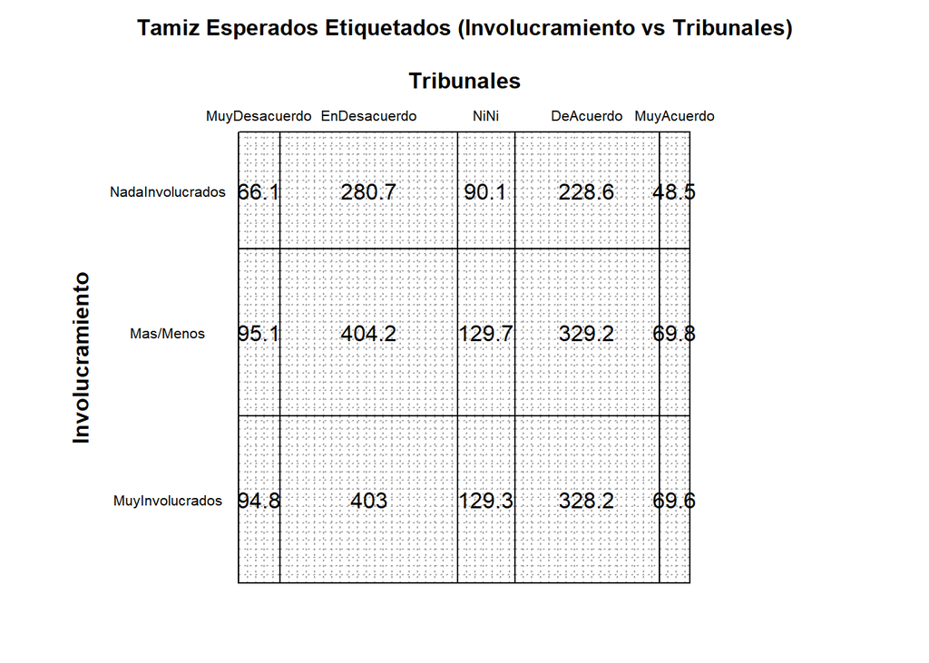

```r
vcd::sieve(do_23,
           shade = TRUE,
           sievetype = "expected",
           labeling = vcd::labeling_values(
             value_type = "expected",
             set_varnames = c(p3f.pdo = "Involucramiento",
                              p6f.gcn = "Tribunales"),
             gp_labels = grid::gpar(fontsize = 8),
             rot_labels = c(left = 0),
             offset_labels = c(left = 3),
             offset_varnames = c(left = 4)),
           gp_text = grid::gpar(fontface = 2),
           main = "Tamiz Esperados Etiquetados (Involucramiento vs Tribunales)",
           main_gp = grid::gpar(fontsize = 12, fontface = "bold"))
```

### Gráfico de tamiz con valores observados etiquetados

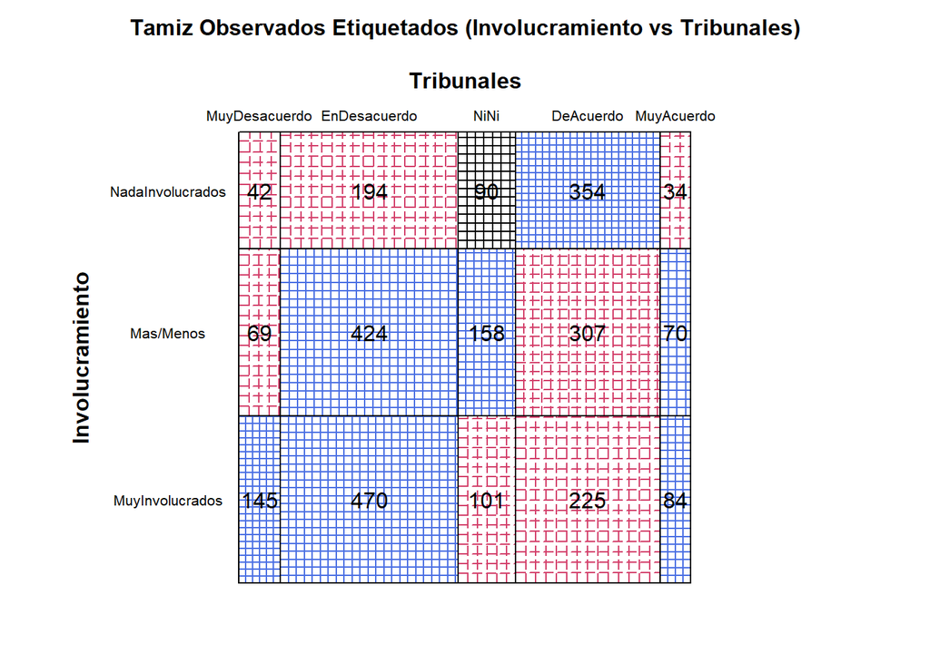

```r
vcd::sieve(do_23,
           shade = TRUE,
           sievetype = "observed",
           labeling = vcd::labeling_values(
             value_type = "observed",
             set_varnames = c(p3f.pdo = "Involucramiento",
                              p6f.gcn = "Tribunales"),
             gp_labels = grid::gpar(fontsize = 8),
             rot_labels = c(left = 0),
             offset_labels = c(left = 3),
             offset_varnames = c(left = 4)),
           gp_text = grid::gpar(fontface = 2),
           main = "Tamiz Observados Etiquetados (Involucramiento vs Tribunales)",
           main_gp = grid::gpar(fontsize = 12, fontface = "bold"))
```

En este gráfico de tamiz de valores observados etiquetados, el bloque de mayor densidad se localiza en el extremo de la desconfianza institucional, específicamente en la intersección de quienes están “En Desacuerdo” con los tribunales y perciben un involucramiento militar “Muy Involucrado”, con una frecuencia observada de 470 casos, lo que representa la celda con mayor volumen de toda la muestra. Este hallazgo, reforzado por el sombreado azul intenso en el cuadrante de desconfianza (“Muy en Desacuerdo” y “Muy Involucrados” con 145 casos), confirma que existe una sobre-representación de ciudadanos que vinculan directamente la ineficiencia judicial con la criminalidad militar en sus regiones.

Por otro lado, el gráfico revela un núcleo de asociación positiva en el polo de la confianza, donde la celda de militares “Nada Involucrados” y ciudadanos “De Acuerdo” con los tribunales registra 354 casos, una cifra significativamente superior a lo que se esperaría si ambas variables no estuvieran relacionadas. En contraste, las celdas con sombreado rojo o áreas más reducidas evidencian las combinaciones de respuesta menos probables, como el hecho de confiar plenamente en la justicia mientras se percibe una alta corrupción militar, o viceversa. Esta distribución etiquetada valida empíricamente la tesis de Von Lampe (2011) sobre cómo la percepción del desempeño estatal es sistémica; la presencia de 1,025 personas que ven un involucramiento militar alto frente a solo 714 que no ven ninguno sugiere que el escepticismo sobre el control del Estado sobre el delito organizado predomina en la muestra de 2,767 hogares.

### Gráfico de tamiz con valores etiquetados esperados por definición política

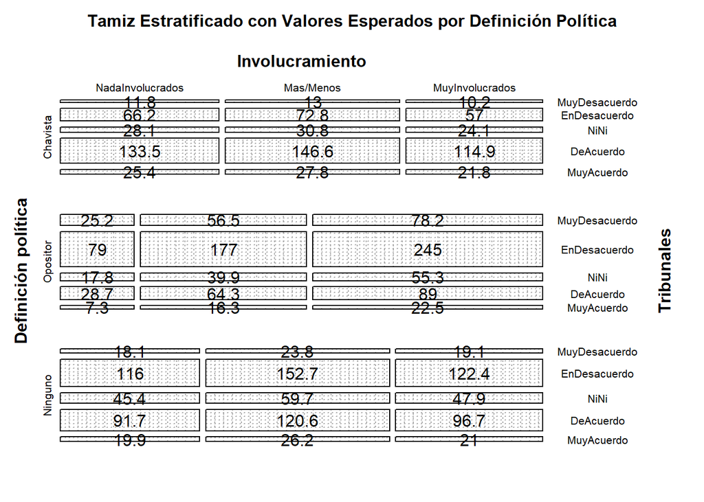

```r
vcd::sieve(~ p3f.pdo + p6f.gcn | dpol,
           data = do_123,
           margins = c(3, 8, 3, 3),
           shade = TRUE,
           sievetype = "expected",
           main = "Tamiz Estratificado con Valores Esperados por Definición Política",
           main_gp = grid::gpar(fontsize = 12, fontface = "bold"),
           labeling = vcd::labeling_values(
             value_type = "expected",
             set_varnames = c(p3f.pdo = "Involucramiento",
                              p6f.gcn = "Tribunales",
                              dpol="Definición política"),
             gp_labels = grid::gpar(fontsize = 8),
             rot_labels = c(right = 0),
             offset_labels = c(right = 3),
             offset_varnames = c(right = 4)
             ))
```

### Gráfico de tamiz con valores etiquetados observados por definición política

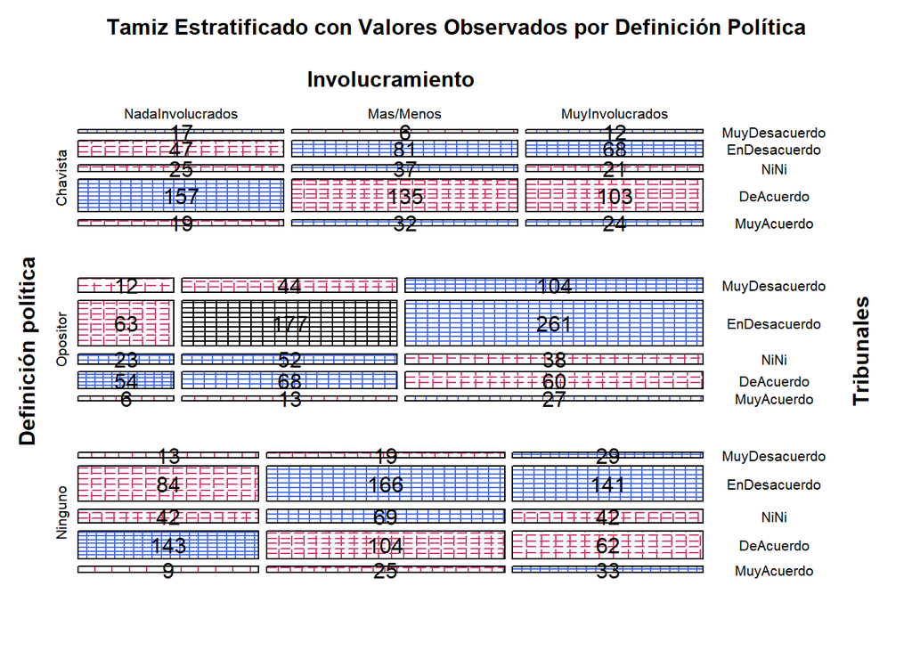

```r
vcd::sieve(~ p3f.pdo + p6f.gcn | dpol,
           data = do_123,
           margins = c(3, 8, 3, 3),
           shade = TRUE,
           sievetype = "observed",
           main = "Tamiz Estratificado con Valores Observados por Definición Política",
           main_gp = grid::gpar(fontsize = 12, fontface = "bold"),
           labeling = vcd::labeling_values(
             value_type = "observed",
             set_varnames = c(p3f.pdo = "Involucramiento",
                              p6f.gcn = "Tribunales",
                              dpol="Definición política"),
             gp_labels = grid::gpar(fontsize = 8),
             rot_labels = c(right = 0),
             offset_labels = c(right = 3),
             offset_varnames = c(right = 4)
             ))
```

Finalmente, el estrato Ninguno muestra el comportamiento de transición más dinámico y simétrico, en el que la concentración de opinión pasa de estar en “De acuerdo” (143 casos) cuando no se percibe involucramiento, a saltar hacia “En desacuerdo” (141 casos) cuando la percepción de involucramiento es alta, constituyendo así el cambio de opinión más limpio del análisis.

### Gráfico de mosaico

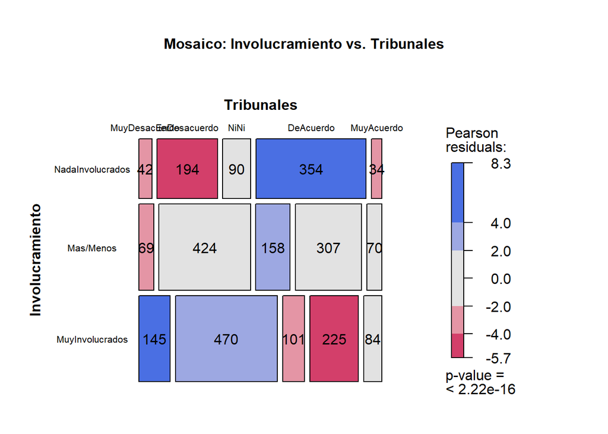

```r
# Usamos la función mosaic pero con el parámetro labeling_args
vcd::mosaic(do_23,
            shade = TRUE,
            legend = TRUE,
            labeling = vcd::labeling_values(
              set_varnames = c(p3f.pdo = "Involucramiento",
                               p6f.gcn = "Tribunales"),
              gp_labels = grid::gpar(fontsize = 8),
              rot_labels = c(left = 0),
              offset_labels = c(left = 3),
              offset_varnames = c(left = 4)
            ),
            gp_text = grid::gpar(fontface = 2, fontsize = 7),
            main = "Mosaico: Involucramiento vs. Tribunales",
            main_gp = grid::gpar(fontsize = 12, fontface = "bold"))
```

Para finalizar este análisis, también se computaron gráficos de mosaicos, primero solo con las variables activas.

Al observar el mosaico, que provee información similar al de tamiz, la interpretación de los residuos tipificados de Pearson mediante el sombreado de color revela que la asociación es estadísticamente significativa en los extremos, tal como indicaban las pruebas de *X<sup>2</sup>* anteriores. El bloque azul intenso en la esquina inferior izquierda muestra un exceso significativo de personas que combinan el “Muy en Desacuerdo” judicial con la percepción de militares “Muy Involucrados”, mientras que el bloque azul en la zona superior derecha destaca el exceso de casos en la combinación de “De Acuerdo” y “Nada Involucrados”. En contraste, las áreas sombreadas en rojo indican vacíos estadísticos donde las frecuencias son mucho menores a lo esperado, confirmando que es muy poco probable encontrar individuos que confíen en los tribunales pero que simultáneamente denuncien un alto involucramiento militar, lo que refuerza la visión sistémica y coherente que los ciudadanos tienen sobre la integridad del Estado.

### Gráfico de mosaico por definición política

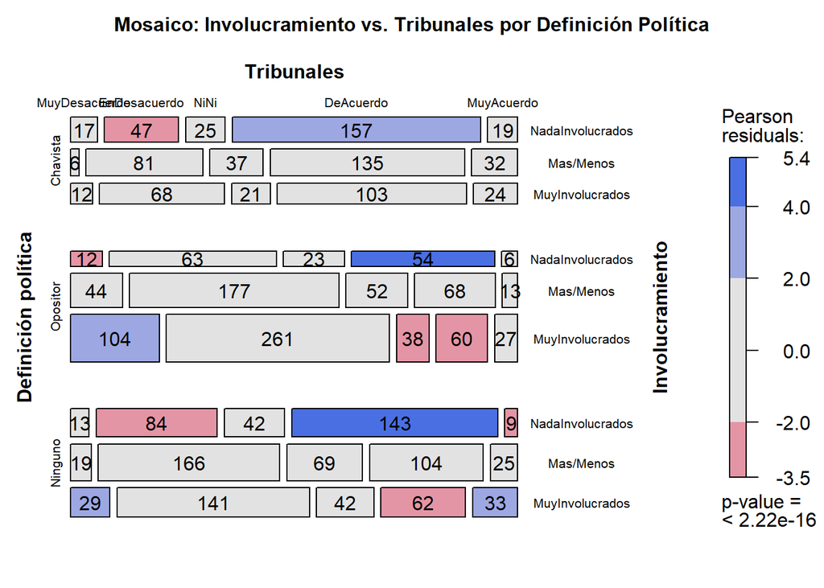

```r
vcd::mosaic(do_123,
            condvar="dpol",
            shade = TRUE,
            # Cambiamos 'pos' por 'space' y eliminamos 'horizontal'
            legend = TRUE,
            legend_pos=1,
            # Márgenes: (abajo, izquierda, arriba, derecha)
            # 12 abajo para la leyenda y 12 a la derecha para las etiquetas
            margins = c(3, 8, 3, 3),
            labeling = vcd::labeling_values(
              set_varnames = c(p3f.pdo = "Involucramiento",
                               p6f.gcn = "Tribunales",
                               dpol = "Definición política"),
              gp_labels = grid::gpar(fontsize = 8),
              rot_labels = c(right = 0),
              # Aleja las categorías del gráfico
              offset_labels = c(right = 3),
              # Aleja el nombre de la variable "Involucramiento" todavía más
              offset_varnames = c(right = 4)
            ),
            gp_text = grid::gpar(fontface = 2, fontsize = 7),
            main = "Mosaico: Involucramiento vs. Tribunales por Definición Política",
            main_gp = grid::gpar(fontsize = 12, fontface = "bold"))
```

# Referencias

Aguilera del Pino, A. M. (2006). *Modelización de tablas de contingencia multidimensionales.* La Muralla, S.A.

R Core Team. (2024). *R: A language and environment for statistical computing*. R Foundation for Statistical Computing.[https://www.R-project.org/](https://www.r-project.org/)

Wickham, H., Averick, M., Bryan, J., Chang, W., McGowan, L. D., François, R., Grolemund, G., Hayes, A., Henry, L., Hester, J., Kuhn, M., Pedersen, T. L., Miller, E., Bache, S. M., Müller, K., Ooms, J., Robinson, D., Seidel, D. P., Spinu, V., … Yutani, H. (2019). Welcome to the tidyverse. *Journal of Open Source Software, 4*(43), 1686. https://doi.org/10.21105/joss.01686

Wickham, H., & Miller, E. (2023). *haven: Import and Export ‘SPSS’, ‘Stata’ and ‘SAS’ Files* (Version 2.5.4) [Computer software].[https://CRAN.R-project.org/package=haven](https://cran.r-project.org/package=haven)

Firke, S. (2023). *janitor: Simple Tools for Examining and Cleaning Dirty Data* (Version 2.2.0) [Computer software].[https://CRAN.R-project.org/package=janitor](https://cran.r-project.org/package=janitor)

Meyer, D., Zeileis, A., & Hornik, K. (2006). The strucplot framework: Visualizing multi-way contingency tables with vcd. *Journal of Statistical Software, 17*(3), 1–48. https://doi.org/10.18637/jss.v017.i03

Friendly, M. (2023). *vcdExtra: ‘vcd’ Extensions and Additions* (Version 0.8-0) [Computer software].[https://CRAN.R-project.org/package=vcdExtra](https://cran.r-project.org/package=vcdExtra)